# Lecture1

### Differentiate between classification and regression problems

- **Classification**: predicting among two or more discrete classes
- **Regrssion**: predicting a continuous value

### Explain machine learning terminology such as features, targets, predictions, training, and error

- **examples** = rows = samples = records = instances (usually denoted by $n$)
- **features** = inputs = predictors = explanatory variables = regressors = independent variables = covariates (usually denoted by $d$)
- **targets** = outputs = outcomes = response variable = dependent variable = labels (if categorical).
- **training** = learning = fitting
- **error**:
  - For classification problems, `score` gives the accuracy of the model, i.e., proportion of correctly predicted
    $$accuracy = \frac{\text{correct predictions}}{\text{total examples}}$$
  - Sometimes you will also see people reporting error, which is usually $1 - accuracy$
  - For regression problems `score` returns somethings called [$R^2$ score](https://scikit-learn.org/stable/modules/generated/sklearn.metrics.r2_score.html#sklearn.metrics.r2_score). (More on this in 573.)
    - The maximum $R^2$ is 1 for perfect predictions.
    - Negative R^2 can be negative which means the performance is really bad.
    - For `DummyRegressor` it returns the mean of the `y` values and R^2 = 0.

### Use DummyClassifier and DummyRegressor as baselines for machine learning problems

- Baseline: A simple machine learning algorithm based on simple rules of thumb. For example,
  - most frequent baseline: always predicts the most frequent label in the training set.
- Baselines provide a way to sanity check your machine learning model.

```python
# scikit-learn DummyClassifier
import pandas as pd
from sklearn.dummy import DummyClassifier

classification_df = pd.read_csv("data/quiz2-grade-toy-classification.csv")
X = classification_df.drop(columns = ["quiz2"])
y = classification_df["quiz2"]

# Create a classifier object
dummy_clf = DummyClassifier(strategy="most_frequent")

# fit the classifier
dummy_clf.fit(X, y);

# predict using the learner classifier
dummy_clf.predict(X)
```

```
array(['not A+', 'not A+', 'not A+', 'not A+', 'not A+', 'not A+',
       'not A+', 'not A+', 'not A+', 'not A+', 'not A+', 'not A+',
       'not A+', 'not A+', 'not A+', 'not A+', 'not A+', 'not A+',
       'not A+', 'not A+', 'not A+'], dtype='<U6')
```

```python
# scikit-learn DummyClassifier
from sklearn.dummy import DummyRegressor

regression_df = pd.read_csv("data/quiz2-grade-toy-regression.csv")

# Create `X` and `y` from the given data
X = regression_df.drop(columns = ["quiz2"])
y = regression_df["quiz2"]

# Create a class object
reg = DummyRegressor()

# Train/fit the model
reg.fit(X,y)

# Assess the model
print(reg.score(X,y))

# Predict on some new data using the trained model
new_example = [0,1,92,90,95,93,92]
reg.predict([new_example])
```

```
0.0
```

```
array([85.95238095])
```

### Explain the fit and predict paradigm and use score method of ML models

- Training data $\rightarrow$ Machine learning algorithm $\rightarrow$ ML model
- Unseen test data + ML model $\rightarrow$ predictions

```python
# Create a class object
clf = DummyClassifier(strategy="most_frequent")

# Train/fit the model
clf.fit(X,y)

# Assess the model
print(clf.score(X,y))

# Predict on some new data using the trained model
new_example = [0,1,92,90,95,93,92]
clf.predict([new_example])
```

```
0.14285714285714285
```

```
array([90])
```

### Broadly describe how decision tree prediction works

- Given: a learned tree and a test example
- Start at the top of the tree. Ask binary questions at each node and follow the appropriate path in the tree. Once you are at a leaf node, you have the prediction.
- Note that the model only considers the features which are in the learned tree and ignores all other features.

### Use DecisionTreeClassifier and DecisionTreeRegressor to build decision trees using scikit-learn

```python
# Let's binarize our toy dataset for simplicity
import numpy as np

classification_df = pd.read_csv("data/quiz2-grade-toy-classification.csv")
X = classification_df.drop(columns = ["quiz2"])
y = classification_df["quiz2"]

X_binary = X.copy()
columns = ["lab1", "lab2", "lab3", "lab4", "quiz1"]
for col in columns:
    X_binary[col] = X_binary[col].apply(
        lambda x: 1 if x >= 90 else 0
    )
from sklearn.tree import DecisionTreeClassifier

# Create a decision tree
model = DecisionTreeClassifier()

# Fit a decision tree
model.fit(X_binary, y)

# Assess the model
model.score(X_binary, y)

new_example = np.array([[0, 1, 0, 0, 1, 1, 1]])
model.predict(new_example)
```

```
array(['A+'], dtype=object)
```

```python
from sklearn.tree import DecisionTreeRegressor

X = regression_df.drop(['quiz2'], axis = 1)
y = regression_df['quiz2']

depth = 4
reg_model = DecisionTreeRegressor(max_depth=depth)
reg_model.fit(X, y)
reg_model.predict(X)
regression_df['predicted_quiz2'] = reg_model.predict(X)
print("R^2 score on the training data: %0.3f\n\n" %(reg_model.score(X,y)))
```

```
R^2 score on the training data: 0.928
```

### Explain the difference between parameters and hyperparameters

- When you call `fit`, a bunch of values get set, like the features to split on and split thresholds.
- These are called **parameters**.
- But even before calling `fit` on a specific data set, we can set some "knobs" that control the learning.
- These are called **hyperparameters**.

#### Hyperparamter vs Parameter

Parameters are the things that a machine learning algorithm "learns" during training. For example, the splits in a decision tree.

Hyperparameters are things we can "tune" to influence how the machine learning algorithm learns the parameters. For example, the max_depth hyperparameter in a decision tree dictates the maximum number of parameters the tree can learn.

- **parameters** are automatically learned by the algorithm during training
- **hyperparameters** are specified based on:
  - expert knowledge
  - heuristics, or
  - systematic/automated optimization (more on that in the coming lectures)

### Explain the concept of decision boundaries

A decision boundary is the region of a problem space in which the output label of a classifier is ambiguous. The classifier will classify all the points on one side of the decision boundary as belonging to one class and all those on the other side as belonging to the other class.

# Lecture2

### Explain how decision boundaries change with the max_depth hyperparameter

As `max_depth` increases, model becomes more complex and decision boundaries becomes more complex.

### Explain the concept of generalization

We want the learner to be able to generalize beyond what it has seen in the training data. Generalization refers to your model's ability to adapt properly to new, previously unseen data, drawn from the same distribution as the one used to create the model.

### Split a dataset into train and test sets using train_test_split function

```
X_train, X_test, y_train, y_test = train_test_split(X, y, test_size=0.2, random_state=123)

                                       OR

train_df, test_df = train_test_split(df, test_size=0.2, random_state=123)
`
```

### Explain the difference between train, validation, test, and "deployment" data

- "Training" data is where we fit our model and learn pattern from
- "Validation" data is where we have access to the target values.
  - But, unlike the training data, we only use this for hyperparameter tuning and model assessment; we don't pass these into `fit`.
- "Test" data is where we have access to the target values
  - But, unlike training and validation data, we neither use it in training nor hyperparameter optimization.
  - We only use it **once** to evaluate the performance of the best performing model on the validation set.
  - We lock it in a "vault" until we're ready to evaluate.
- "Deployment" data
  - After we build and finalize a model, we deploy it, and then the model deals with the data in the wild.
  - We will use "deployment" to refer to this data, where we do **not** have access to the target values.
  - Deployment error is the thing we *really* care about.
  - We use validation and test errors as proxies for deployment error, and we hope they are similar.
  - So, if our model does well on the validation and test data, we hope it will do well on deployment data.

#### Summary of train, validation, test, and deployment data

|  | `fit` | `score` | `predict` |
| --- | --- | --- | --- |
| Train | ✔️ | ✔️ | ✔️ |
| Validation |  | ✔️ | ✔️ |
| Test |  | once | once |
| Deployment |  |  | ✔️ |

You can typically expect $E_{train} < E_{validation} < E_{test} < E_{deployment}$.

### Identify the difference between training error, validation error, and test error

- $E_\textrm{train}$ is your training error (or mean train error from cross-validation).
  - When training your model, you train it on the training data. Your performance on the training data/the training error does not tell you how well your model is overall, but only how well it has learned the training data.
- $E_\textrm{valid}$ is your validation error (or mean validation error from cross-validation).
  - The validation error tells you how well your learned model generalises, that means how well it fits to data that it has not been trained on.
- $E_\textrm{test}$ is your test error.
  - If your model is finally trained and done, you can test it on the testing data and see how well it performs with completely unseen data
- $E_\textrm{best}$ is the best possible error you could get for a given problem.

### Explain cross-validation and use cross_val_score and cross_validate to calculate cross-validation error

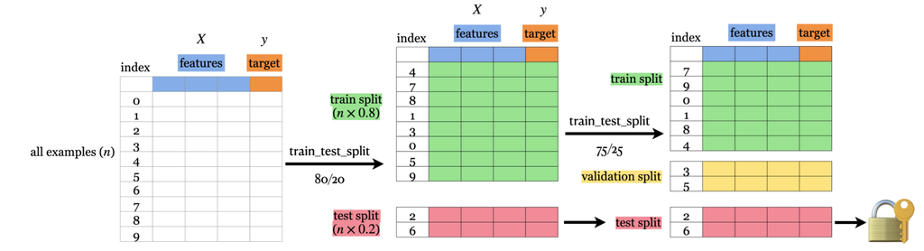

**Problems with having a single train/validation split**

- Only using a portion of your data for training and only a portion for validation.
- If your dataset is small you might end up with a tiny training and/or validation set.
- You might be unlucky with your splits such that they don't align well or don't well represent your test data.

**How cross validation works?**

```
cross_val_score(model, X_train, y_train, cv=10)

                        AND

cross_validate(model, X_train, y_train, cv=10, return_train_score=True)
```

### Explain overfitting, underfitting, and the fundamental tradeoff

Underfitting: Both the training error and validation error are very high and difference between them is smaller.

Good Model: Has highest validation score and the gap between training and validation error is not large.

#### The "fundamental tradeoff" of supervised learning:

As you increase model complexity, $E_\textrm{train}$ tends to go down but $E_\textrm{valid}-E_\textrm{train}$ tends to go up.

- If your model is very simple, like `DummyClassifier`, then you won't really learn any "specific patterns" of the training set, but your model won't be very good in general. This is underfitting.
- If your model is very complex, like a `DecisionTreeClassifier(max_depth=None)`, then you will learn unreliable patterns that get every single training example correct, but there will be a huge gap between training error and validation error. This is overfitting.

#### Bias vs variance tradeoff

- This fundamental trade-off is also called the bias/variance tradeoff.
- Bias $\rightarrow$ the tendency to consistently learn the same wrong thing (high bias means underfitting)
- Variance $\rightarrow$ the tendency to learn random things irrespective of the real signal (high variance means overfitting)

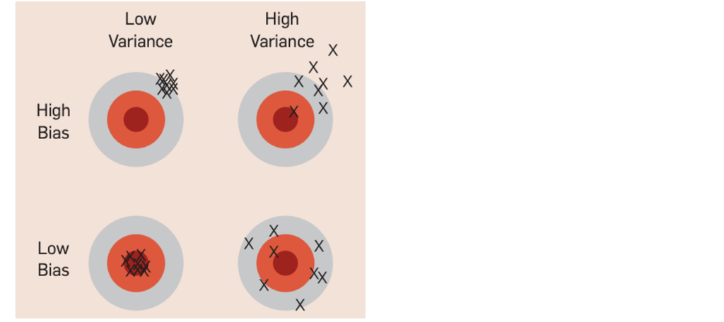

- Low variance and low bias means a good model.
- Low bias and high variance means overfitting.
- High bias and high variance means a very bad model.
- High bias and low variance means underfitting.

### State the golden rule

- Even though we care the most about test error **THE TEST DATA CANNOT INFLUENCE THE TRAINING PHASE IN ANY WAY**.
- We have to be very careful not to violate it while developing our ML pipeline.
- Even experts end up breaking it sometimes which leads to misleading results and lack of generalization on the real data.

#### Here is the workflow we'll generally follow.

- **Splitting**: Before doing anything, split the data `X` and `y` into `X_train`, `X_test`, `y_train`, `y_test` or `train_df` and `test_df` using `train_test_split`.
- **Select the best model using cross-validation**: Use `cross_validate` with `return_train_score = True` so that we can get access to training scores in each fold. (If we want to plot train vs validation error plots, for instance.)
- **Scoring on test data**: Finally score on the test data with the chosen hyperparameters to examine the generalization performance.

### Q & A

**Question**: Suppose for a particular feature, the histograms of that feature are identical for the two target classes. Does that mean the feature is not useful for predicting the target class?

**Question**: Do you expect `DummyClassifier` to be sensitive to data shuffling and splitting?

**Answer**: Yes, `DummyClassifier` can be sensitive to data shuffling and splitting. For instance, it is possible that the training data only contains positive examples and test data only contains negative examples. The test accuracy would be 0 in that case.

**Question**: Why can't you simply pick the value of `min_samples_split` that does best on the training data? Why do we have to treat it like a hyperparameter rather than a parameter?

**Question**: When using the `SimpleImputer` transformer on the numeric columns, is there any problem with calling `fit_transform` on the test split? Why or why not?

**Answer**: Yes, calling `fit_transform` on the test split when imputing missing values with `SimpleImputer` transformer is problematic, especially with numeric features. Here we are using the strategy of imputing values with the median value and if we call `fit` on test split, it'll impute the missing values with the median of the test examples and not train examples, which is a subtle violation of the golden rule.

**Question**: Is scaling necessary for decision trees? Why or why not?

**Answer**: It doesn't seem to have much impact on the decision tree classifier, which makes sense. In principle, tree-based algorithms should be indifferent to scaling and should be able to deal with nominal features. But the `scikit-learn` implementation of the decision tree algorithm requires numeric values for branching.

### Practice

1. We carry out cross-validation to avoid reusing the same validation set again and again. With $k$-fold cross-validation, you split your $n$ examples into $k$ folds. For each fold, you train on 3 examples

   ```
    1. n
    2. n/k
    3. n - n/k  or n(k-1)/k
    4. k
   ```

1. With $k$-fold cross-validation, you split your $n$ examples into $k$ folds. For each fold, when you are done, you add up the accuracies from each fold and divide by 4

   ```
    1. n
    2. n/k
    3. n - n/k or n(k-1)/k
    4. k
   ```

1. In supervised learning, the training error is always lower than the validation error.

   > False. When training set has some hard cases to learn and validation set is easy to predict.
2. The fundamental tradeoff of ML states that as training error goes down, validation error goes up.

   > False. Trade off is when training error goes down, the gap between training error and validation error goes up.
3. More "complicated" models are more likely to overfit than "simple" ones.

   > True. Over-complicated model does not generalize unseen data well which is overfitting.
4. If we had an infinite amount of training data, overfitting would not be a problem.

   > True. If we have all the data in the world, there is no danger capture unreal patterns.
5. If our training error is extremely low, that means we're overfitting.

   > False. It depends on how hard to train the dataset. If validation error is very low as well, we might just get a good model instead of overfitting.
1. Unlike with decision trees, with $k$-NNs most of the work is done at the `predict` stage.

   > True. kNN is lazy training which only stores all data points while training but calculates distance between query point and all test data during prediction.
2. With $k$-NN, setting the hyperparameter $k$ to larger values typically reduces training error.

   > False. Too large k suffers curse of dimensionality.
3. $k$-NN may perform poorly in high-dimensional space (say, *d* > 100).

   > True. We can have a lot of irrelevant features and it suffers curse of dimensionality.
4. Similar to decision trees, $k$-NNs finds a small set of good features.

   > False. kNN is a non-parametric model and uses all features while prediction.
1. Similar to KNN, SVM with RBF kernel is a non-parametric model.

   > False. Since SVM only stores support vectors but if it decides to store all data points as support vectors it is a non-parametric model. It really depends on the size of dataset and the pattern of dataset.
2. In SVM RBF, removing a non-support vector does not change the decision boundary.

   > True. SVM RBF only uses support vectors to make predictions.
3. In sklearn’s SVC classifier, large values of gamma tend to result in higher training score but probably lower validation score.

   > True. Larger values of gamma means higher complexity of model which might cause overfitting.